# Graphic Analysis of Lottery Data

coop711

2015년 3월 14일

## Lottery Data Input

- Pick-it 1976 New Jersey Lottery Game

```r
lottery <- read.table("../data/lottery.txt",header=T)
str(lottery)
```

```
## 'data.frame':    254 obs. of  2 variables:
##  $ lottery.number: int  810 156 140 542 507 972 431 981 865 499 ...
##  $ lottery.payoff: num  190 120 286 184 384 ...
```

```r
kable(head(lottery), align = "c")
```

| lottery.number | lottery.payoff |
| --- | --- |
| 810 | 190.0 |
| 156 | 120.5 |
| 140 | 285.5 |
| 542 | 184.0 |
| 507 | 384.5 |
| 972 | 324.5 |

- 기초통계량을 계산하고 `lottery.number`의 경우 이론값과 비교. 이론값이라 함은?

```r
kable(t(sapply(lottery, summary)))
```

|  | Min. | 1st Qu. | Median | Mean | 3rd Qu. | Max. |
| --- | --- | --- | --- | --- | --- | --- |
| lottery.number | 0 | 230.00 | 440.50 | 472.23 | 734.5 | 999.0 |
| lottery.payoff | 83 | 194.25 | 270.25 | 290.36 | 364.0 | 869.5 |

```r
kable(t(apply(lottery, 2, sd)), align = "c")
```

| lottery.number | lottery.payoff |
| --- | --- |
| 294.48 | 128.89 |

## Graphic Analysis on lottery.number

- 당첨번호는 0(사실상 000)에서 999 사이에 254회 추출한 랜덤표본으로 볼 수 있음. `stem()`을 이용하여 줄기-잎 그림을 그리고, 히스토그램 작성.

```r
stem(lottery$lottery.number, scale = 0.5)
```

```
##
##   The decimal point is 2 digit(s) to the right of the |
##
##   0 | 0011111222223345777888999
##   1 | 01111111112223446666777888999
##   2 | 0000112233334444455555666677788999
##   3 | 00011111123445566667889
##   4 | 0000111122333334457777888889
##   5 | 00011122222334444456688
##   6 | 0002224555566668889999
##   7 | 0001134444556667778888
##   8 | 11111334455566678899
##   9 | 01112222344455566667888899
##   10 | 00
```

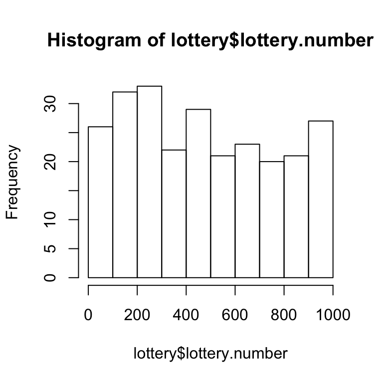

```r
h10<-hist(lottery$lottery.number)
```

- 메인 타이틀과 x축의 좌표이름, y축의 좌표이름의 디폴트값이 어떻게 주어지는지 살피고, 히스토그램 작성에 계산된 값들 확인(특히 `$breaks`, `$counts`, `$density` 유의)

```r
list(breaks=h10$breaks, counts=h10$counts, density=h10$density)
```

```
## $breaks
##  [1]    0  100  200  300  400  500  600  700  800  900 1000
##
## $counts
##  [1] 26 32 33 22 29 21 23 20 21 27
##
## $density
##  [1] 0.00102362 0.00125984 0.00129921 0.00086614 0.00114173 0.00082677
##  [7] 0.00090551 0.00078740 0.00082677 0.00106299
```

- 각 계급의 경계선에 있는 관찰값들을 어떻게 처리하는 지 몇 가지 조건을 바꿔가면서 관찰. `right=F`로 인하여 `$counts`가 어덯게 변하였는가? `attach()`의 역할은 무엇인가?. (작업을 끝내기 전에 반드시 `detach()`할 것). 실제 취하는 값을 1000에서 999로 바꿨을 때, 그리고 `include.lowest=F`로 했을 때 각각 어떤 일이 일어나는지 확인하고 이유를 생각해 볼 것. `list()`로 표현하려는 것은 무엇이며 이름을 붙인 까닭은?

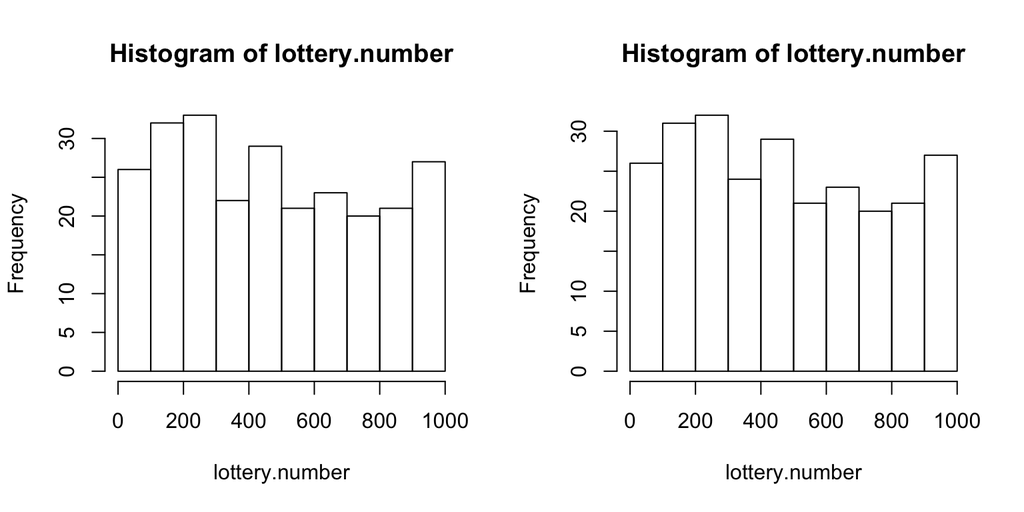

```r
attach(lottery)
par(mfrow=c(1,2))
h10.2<-hist(lottery.number, breaks=seq(0,1000,by=100),include.lowest=T)
h10.3<-hist(lottery.number, breaks=seq(0,1000,by=100),right=F)
```

```r
list(breaks=h10.2$breaks, counts=h10.2$counts, density=h10.2$density)
```

```
## $breaks
##  [1]    0  100  200  300  400  500  600  700  800  900 1000
##
## $counts
##  [1] 26 32 33 22 29 21 23 20 21 27
##
## $density
##  [1] 0.00102362 0.00125984 0.00129921 0.00086614 0.00114173 0.00082677
##  [7] 0.00090551 0.00078740 0.00082677 0.00106299
```

```r
list(breaks=h10.3$breaks, counts=h10.3$counts, density=h10.3$density)
```

```
## $breaks
##  [1]    0  100  200  300  400  500  600  700  800  900 1000
##
## $counts
##  [1] 26 31 32 24 29 21 23 20 21 27
##
## $density
##  [1] 0.00102362 0.00122047 0.00125984 0.00094488 0.00114173 0.00082677
##  [7] 0.00090551 0.00078740 0.00082677 0.00106299
```

- `breaks` 대신 `nclass=10` 을 사용하였을 때 결과 비교.

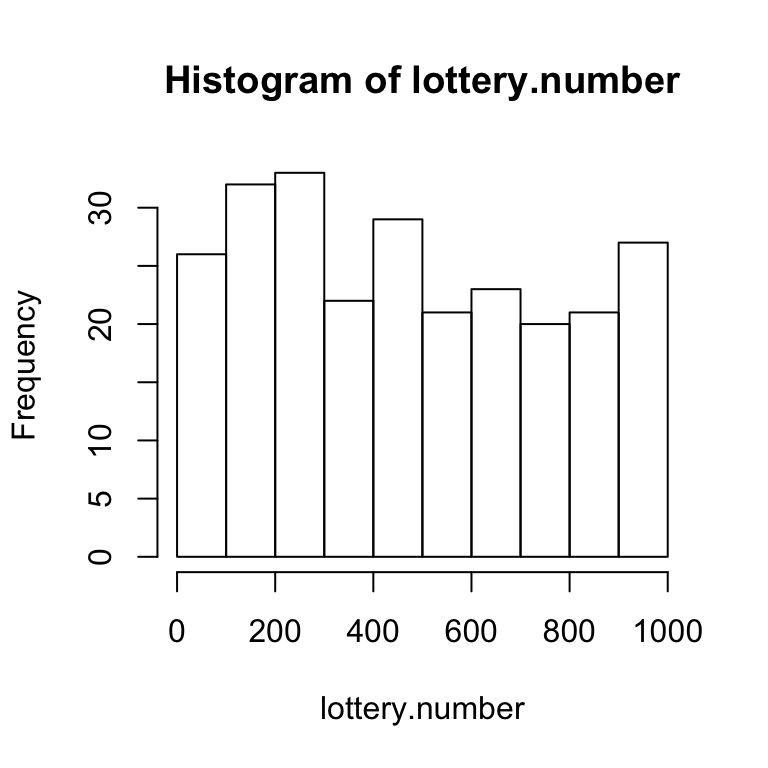

```r
par(mfrow=c(1,1))
h10.4<-hist(lottery.number, nclass=10)
```

```r
list(breaks=h10.4$breaks, counts=h10.4$counts, density=h10.4$density)
```

```
## $breaks
##  [1]    0  100  200  300  400  500  600  700  800  900 1000
##
## $counts
##  [1] 26 32 33 22 29 21 23 20 21 27
##
## $density
##  [1] 0.00102362 0.00125984 0.00129921 0.00086614 0.00114173 0.00082677
##  [7] 0.00090551 0.00078740 0.00082677 0.00106299
```

- 다양한 `nclass` 값에 대하여 히스토그램 작성. `nclass`로 요구했을 때 제대로 잘 작동하는가 확인.

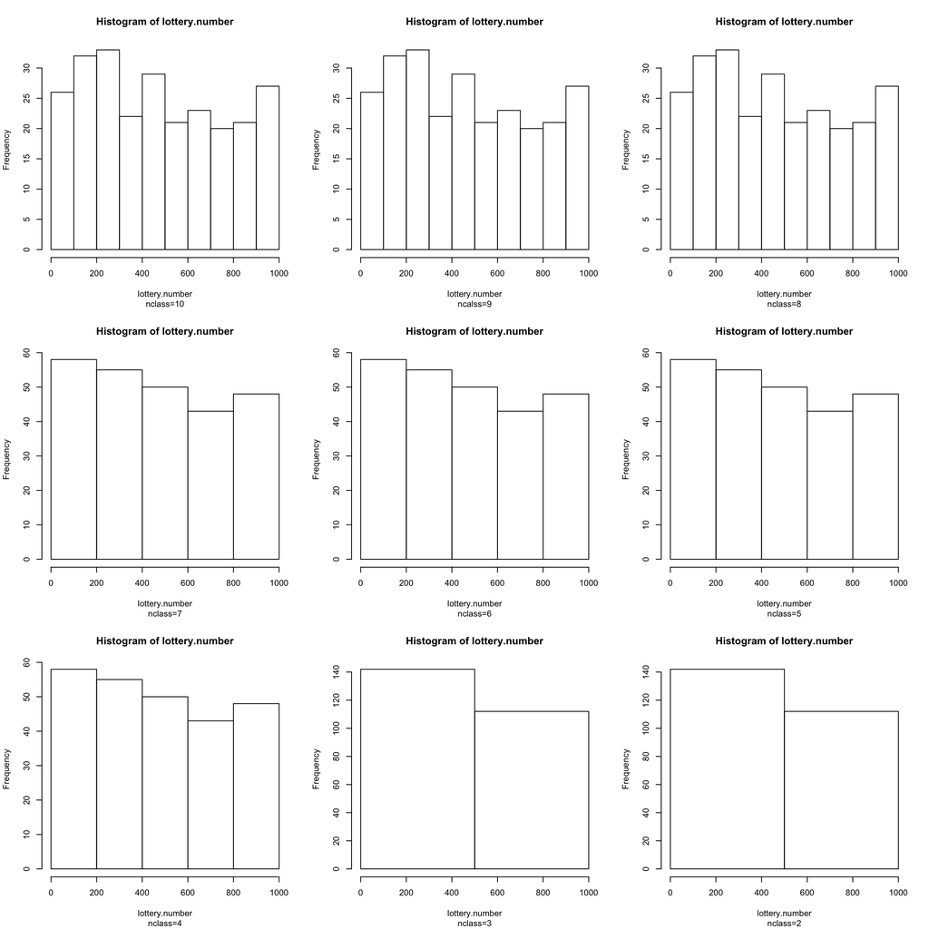

```r
opar<-par(no.readonly=TRUE)
par(mfrow=c(3,3))
hist(lottery.number, nclass=10, sub="nclass=10")
hist(lottery.number, nclass=9, sub="ncalss=9")
hist(lottery.number, nclass=8, sub="nclass=8")
hist(lottery.number, nclass=7, sub="nclass=7")
hist(lottery.number, nclass=6, sub="nclass=6")
hist(lottery.number, nclass=5, sub="nclass=5")
hist(lottery.number, nclass=4, sub="nclass=4")
hist(lottery.number, nclass=3, sub="nclass=3")
hist(lottery.number, nclass=2, sub="nclass=2")
```

이 작업은 `mapply()`를 이용하면 훨씬 간단하게 처리할 수 있다. `lottery.number`를 `list`로 변환해서 반복 사용할 수 있도록 작업한 데 유의하라.

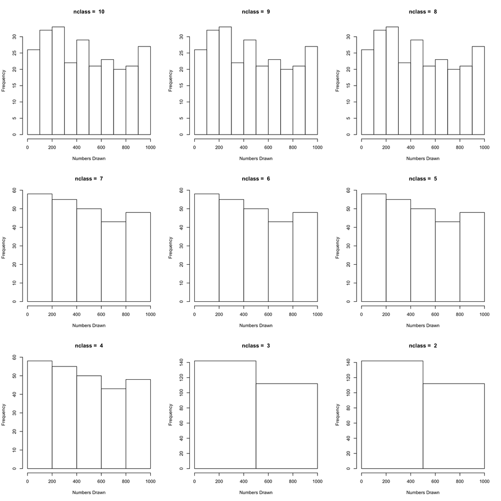

```
##          [,1]               [,2]               [,3]
## breaks   Numeric,11         Numeric,11         Numeric,11
## counts   Integer,10         Integer,10         Integer,10
## density  Numeric,10         Numeric,10         Numeric,10
## mids     Numeric,10         Numeric,10         Numeric,10
## xname    "dots[[1L]][[1L]]" "dots[[1L]][[2L]]" "dots[[1L]][[3L]]"
## equidist TRUE               TRUE               TRUE
##          [,4]               [,5]               [,6]
## breaks   Numeric,6          Numeric,6          Numeric,6
## counts   Integer,5          Integer,5          Integer,5
## density  Numeric,5          Numeric,5          Numeric,5
## mids     Numeric,5          Numeric,5          Numeric,5
## xname    "dots[[1L]][[4L]]" "dots[[1L]][[5L]]" "dots[[1L]][[6L]]"
## equidist TRUE               TRUE               TRUE
##          [,7]               [,8]               [,9]
## breaks   Numeric,6          Numeric,3          Numeric,3
## counts   Integer,5          Integer,2          Integer,2
## density  Numeric,5          Numeric,2          Numeric,2
## mids     Numeric,5          Numeric,2          Numeric,2
## xname    "dots[[1L]][[7L]]" "dots[[1L]][[8L]]" "dots[[1L]][[9L]]"
## equidist TRUE               TRUE               TRUE
```

```r
par(mfrow=c(3,3))
mapply(hist, rep(list(lottery$lottery.number), 9), xlab="Numbers Drawn", nclass=10:2, main=paste("nclass = ", 10:2))
```

- `nclass=9, 8`은 모두 `nclass=10`과 같고, `nclass=7, 6, 4`는 모두 `nclass=5`와 같으며, `nclass=3` 인 경우도 요구와 다르게 나온 점에 유의하고 일부 계산값 확인. argument 중에 `sub="nclass=3"` 을 놓아 둔채 `plot=F` 를 하면 어떻게 되는지 시험해 보시오.

```r
par(mfrow=c(1,2))
h4<-hist(lottery.number, nclass=4, plot=F)
h3<-hist(lottery.number, nclass=3, plot=F)
list(breaks=h4$breaks, counts=h4$counts, density=h4$density)
```

```
## $breaks
## [1]    0  200  400  600  800 1000
##
## $counts
## [1] 58 55 50 43 48
##
## $density
## [1] 0.00114173 0.00108268 0.00098425 0.00084646 0.00094488
```

```r
list(breaks=h3$breaks, counts=h3$counts, density=h3$density)
```

```
## $breaks
## [1]    0  500 1000
##
## $counts
## [1] 142 112
##
## $density
## [1] 0.00111811 0.00088189
```

- `nclass=4`, `nclass=3` 을 그리려면 `breaks` 조정. `breaks` 가 보다 확실한 방법!!

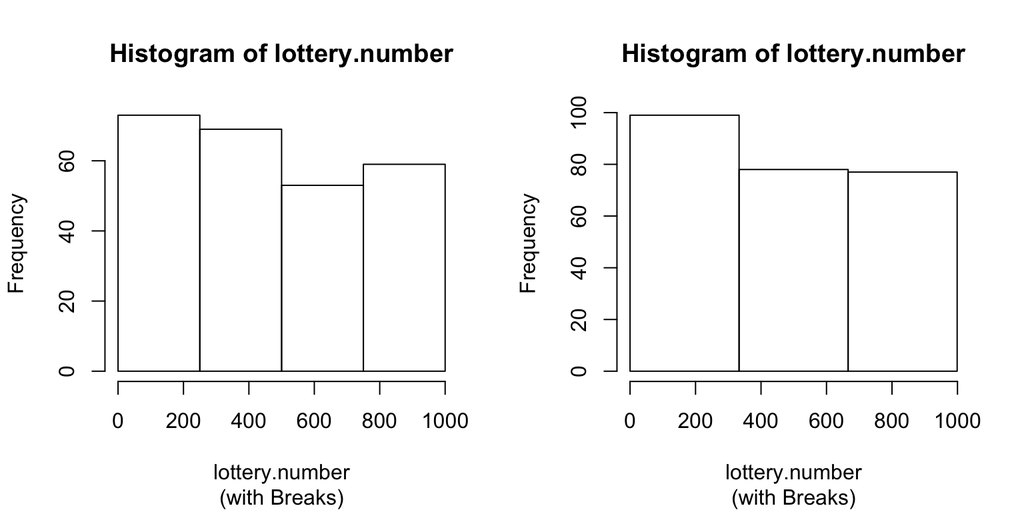

```r
par(mfrow=c(1,2))
h4.breaks<-hist(lottery.number, breaks=seq(0,1000, by=250), sub="(with Breaks)")
h3.breaks<-hist(lottery.number, breaks=seq(0,999, by=333), sub="(with Breaks)")
```

```r
list(breaks=h4.breaks$breaks, counts=h4.breaks$counts, density=h4.breaks$density)
```

```
## $breaks
## [1]    0  250  500  750 1000
##
## $counts
## [1] 73 69 53 59
##
## $density
## [1] 0.00114961 0.00108661 0.00083465 0.00092913
```

```r
list(breaks=h3.breaks$breaks, counts=h3.breaks$counts, density=h3.breaks$density)
```

```
## $breaks
## [1]   0 333 666 999
##
## $counts
## [1] 99 78 77
##
## $density
## [1] 0.00117046 0.00092218 0.00091036
```

- `breaks`로 계급의 갯수 조정.

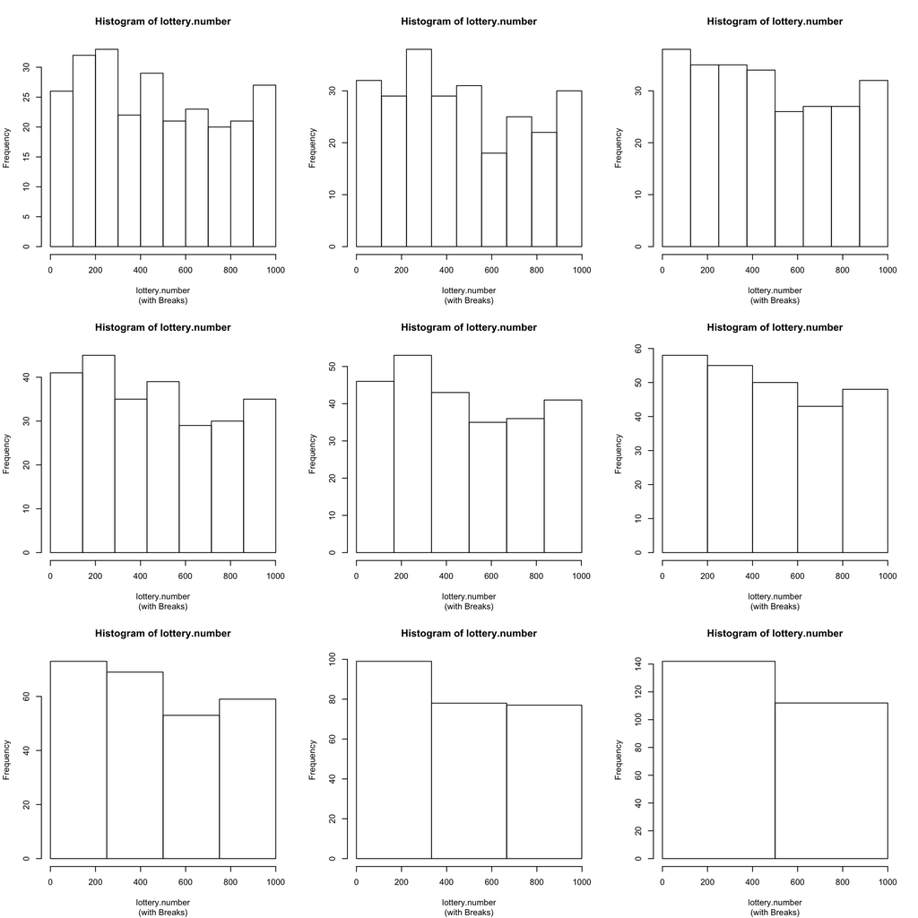

```r
opar<-par(no.readonly=TRUE)
par(mfrow=c(3,3))
hist(lottery.number, breaks=seq(0,1000, by=100), sub="(with Breaks)")
hist(lottery.number, breaks=seq(0,999, by=111), sub="(with Breaks)")
hist(lottery.number, breaks=seq(0,1000, by=125), sub="(with Breaks)")
hist(lottery.number, breaks=seq(0,1001, by=143), sub="(with Breaks)")
hist(lottery.number, breaks=seq(0,1002, by=167), sub="(with Breaks)")
hist(lottery.number, breaks=seq(0,1000, by=200), sub="(with Breaks)")
hist(lottery.number, breaks=seq(0,1000, by=250), sub="(with Breaks)")
hist(lottery.number, breaks=seq(0,999, by=333), sub="(with Breaks)")
hist(lottery.number, breaks=seq(0,1000, by=500), sub="(with Breaks)")
```

이 또한 `mapply`를 활용하여 보다 간단히 할 수 있다.

```r
breaks.number<-list(nclass.10=seq(0,1000, by=100), nclass.9=seq(0,999, by=111), nclass.8=seq(0,1000, by=125), nclass.7=seq(0,1001, by=143), nclass.6=seq(0,1002, by=167), nclass.5=seq(0,1000, by=200), nclass.4=seq(0,1000, by=250), nclass.3=seq(0,999, by=333), nclass.2=seq(0,1000, by=500))
```

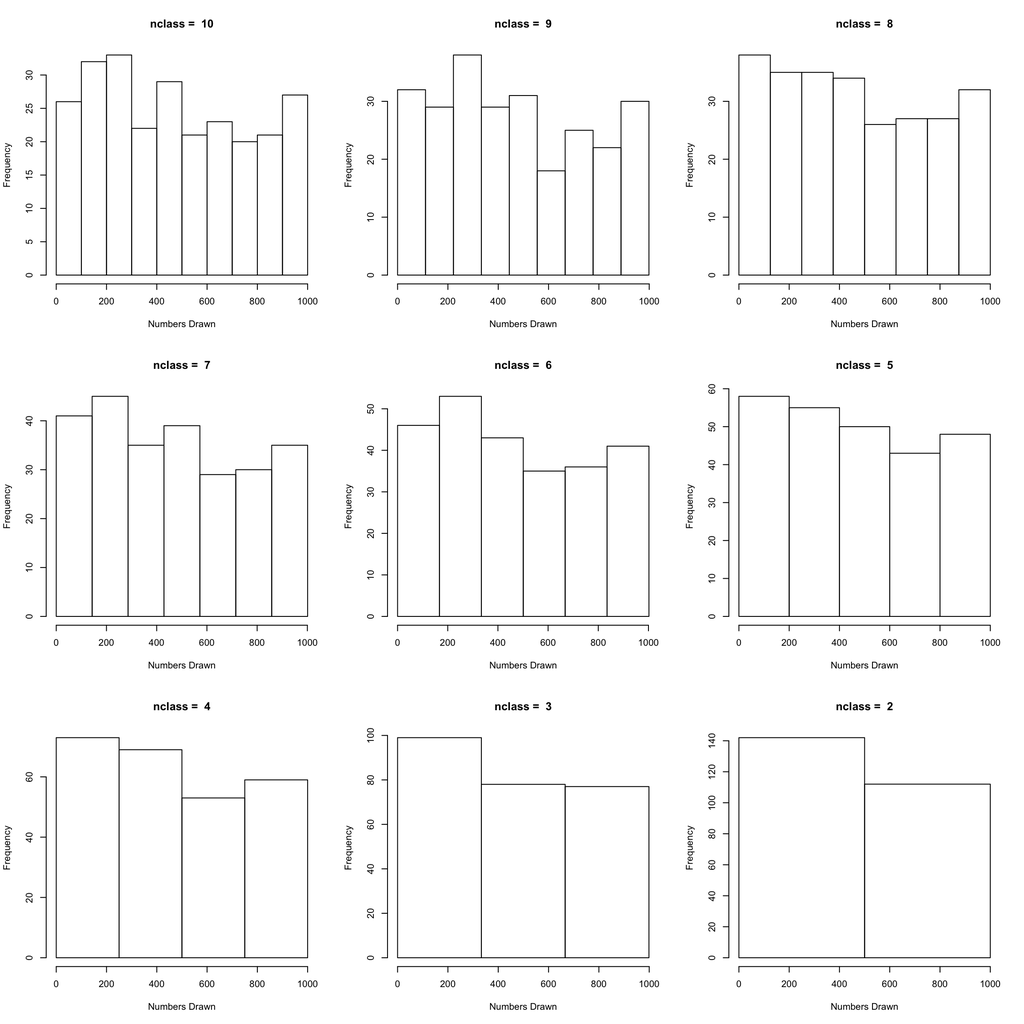

```
##          [,1]               [,2]               [,3]
## breaks   Numeric,11         Numeric,10         Numeric,9
## counts   Integer,10         Integer,9          Integer,8
## density  Numeric,10         Numeric,9          Numeric,8
## mids     Numeric,10         Numeric,9          Numeric,8
## xname    "dots[[1L]][[1L]]" "dots[[1L]][[2L]]" "dots[[1L]][[3L]]"
## equidist TRUE               TRUE               TRUE
##          [,4]               [,5]               [,6]
## breaks   Numeric,8          Numeric,7          Numeric,6
## counts   Integer,7          Integer,6          Integer,5
## density  Numeric,7          Numeric,6          Numeric,5
## mids     Numeric,7          Numeric,6          Numeric,5
## xname    "dots[[1L]][[4L]]" "dots[[1L]][[5L]]" "dots[[1L]][[6L]]"
## equidist TRUE               TRUE               TRUE
##          [,7]               [,8]               [,9]
## breaks   Numeric,5          Numeric,4          Numeric,3
## counts   Integer,4          Integer,3          Integer,2
## density  Numeric,4          Numeric,3          Numeric,2
## mids     Numeric,4          Numeric,3          Numeric,2
## xname    "dots[[1L]][[7L]]" "dots[[1L]][[8L]]" "dots[[1L]][[9L]]"
## equidist TRUE               TRUE               TRUE
```

```r
par(mfrow=c(3,3))
mapply(hist, rep(list(lottery$lottery.number), 9), xlab="Numbers Drawn", breaks=breaks.number, main=paste("nclass = ", 10:2))
```

- 히스토그램의 정보를 보다 알기 쉽게 타이틀과 좌표명을 손보려면 `ann=F` 사용. 다른 히스토그램들에도 적용해 볼 것.

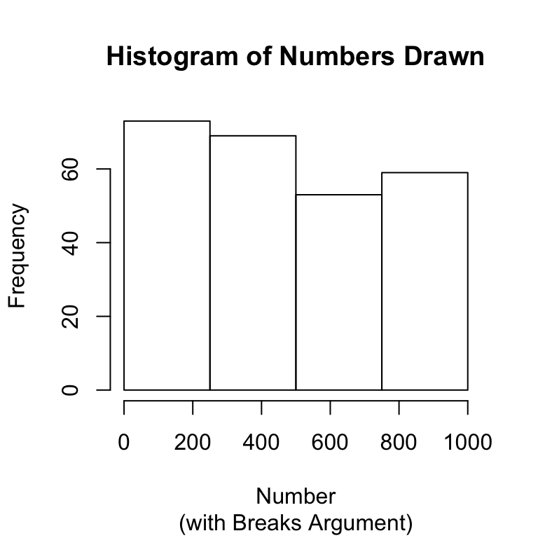

```r
par(mfrow=c(1,1))
hist(lottery.number, breaks=seq(0,1000,by=250),ann=F)
title(main="Histogram of Numbers Drawn", sub="(with Breaks Argument)", xlab="Number", ylab="Frequency")
```

## Distribution of lottery.payoff

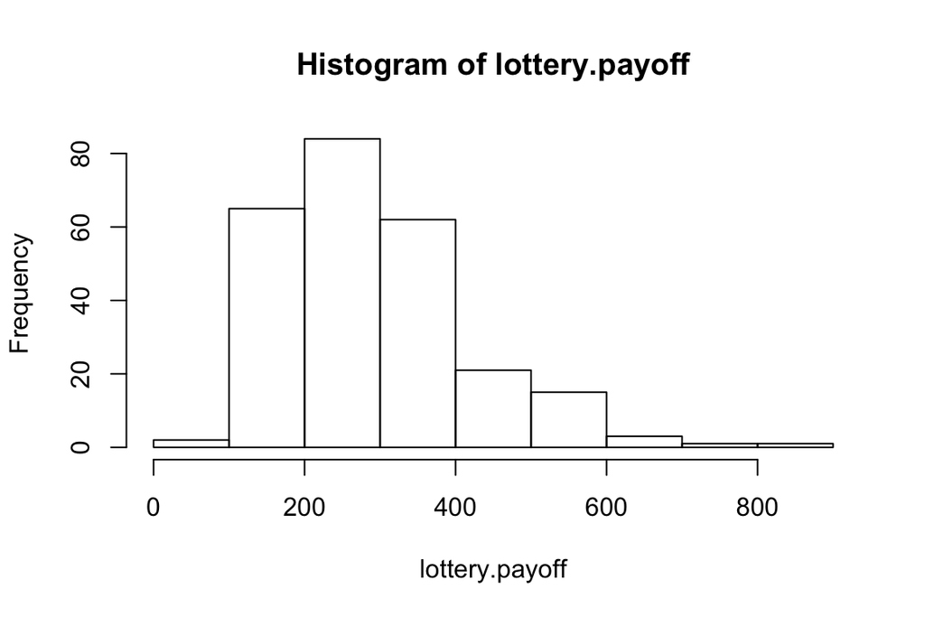

```r
hist(lottery.payoff)
```

- 평균과 중앙값을 계산하여 화살표와 점선으로 표시하면 다음과 같이 할 수 있는데, 어느 것이 평균이고, 어느 것이 중앙값인가?

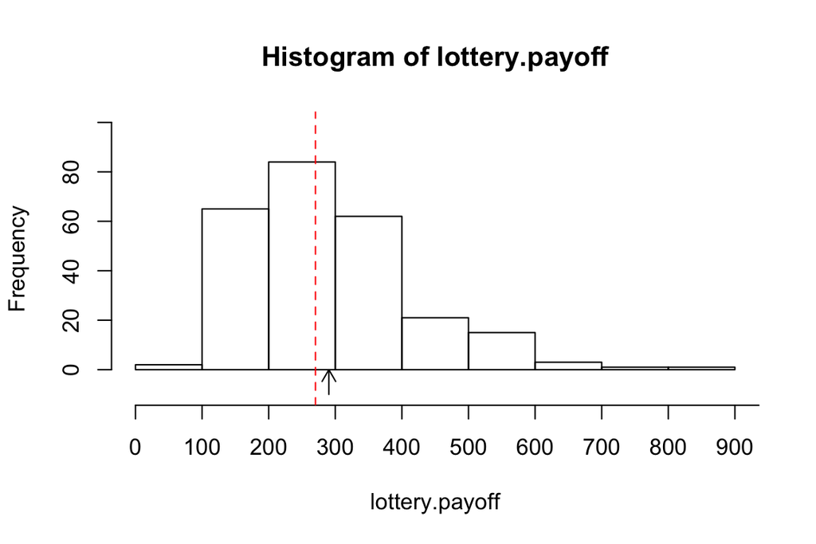

```r
mean.payoff<-mean(lottery.payoff)
med.payoff<-median(lottery.payoff)
hist(lottery.payoff,axes=F,ylim=c(-10,100))
axis(side=1,at=seq(0,1000,by=100),labels=paste(seq(0,1000,by=100)))
arrows(x0=mean.payoff,y0=-10, x1=mean.payoff, y1=0, length=0.1, code=2)
abline(v=med.payoff,lty=2,col="red")
axis(side=2,at=seq(0,100,by=20),labels=paste(seq(0,100,by=20)))
```

- 확률 히스토그램으로 바꾸고 중앙값의 왼쪽 부분에 빗금을 그었다. 전체 면적의 1/2이 모여 있는 것으로 보이는가?

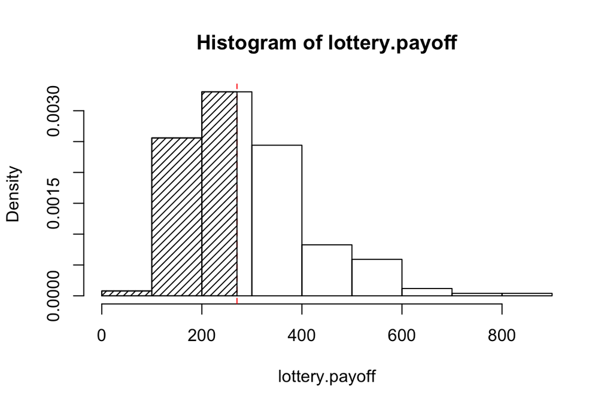

```r
h.payoff<-hist(lottery.payoff, plot=F)
hist(lottery.payoff, prob=T)
abline(v=med.payoff,lty=2,col="red")
x.polygon<-c(h.payoff$breaks[1:3], rep(c(med.payoff,rev(h.payoff$breaks[1:3])), each=2))
y.polygon<-c(rep(0,4), rep(rev(h.payoff$density[1:3]), each=2), 0)
polygon(x=x.polygon, y=y.polygon, density=20)
```

## The Relationship between lottery.number and lottery.payoff

- 이제 두 변수의 산점도를 그려보자.

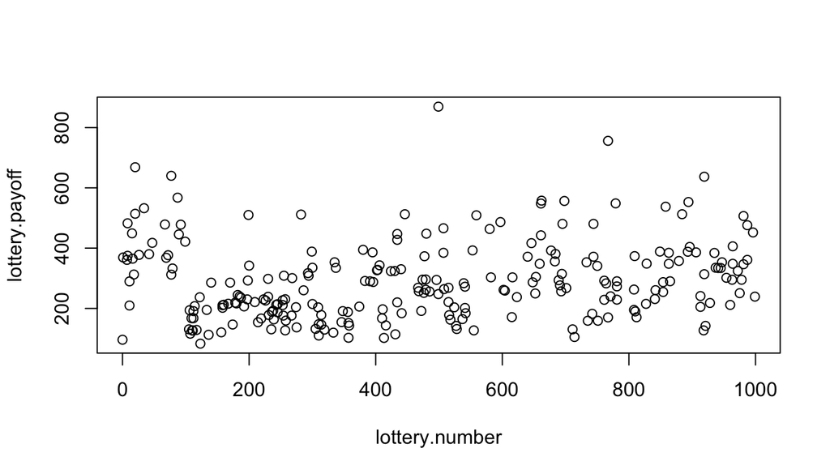

```r
plot(lottery.number, lottery.payoff)
```

- 점의 모양을 바꾸고, 당첨금액이 600불 이상인 당첨번호들을 찾기 위하여 `identify()` 함수를 이용하면 마우스로 직접 찾을 수 있으나 r markdown 에서는 작동하지 않음.

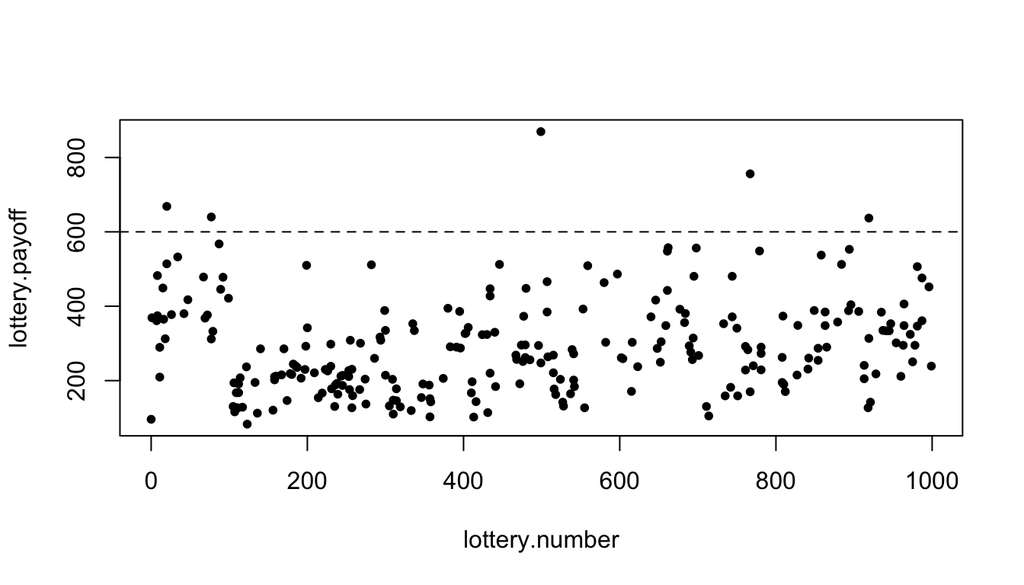

```
## integer(0)
```

```r
plot(lottery.number, lottery.payoff,pch=20)
abline(h=600,lty=2)
identify(lottery.number, lottery.payoff, n=5, labels=paste(lottery.number))
```

- `which()` 함수와 subscripting(`[ ]`) 을 이용하여 찾아보면

```r
high.payoff<-which(lottery.payoff>=600)
high.payoff
```

```
## [1]  10  11  95 107 215
```

```r
lottery.number[high.payoff]
```

```
## [1] 499  20  77 767 919
```

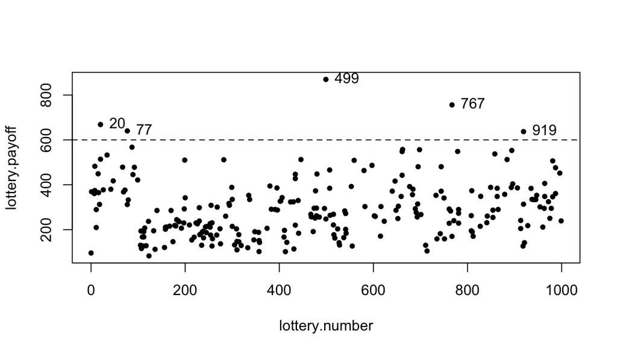

```r
plot(lottery.number, lottery.payoff,pch=20)
abline(h=600,lty=2)
text(x=lottery.number[high.payoff],y=lottery.payoff[high.payoff],labels=lottery.number[high.payoff],pos=4)
```

- 당첨금액 상위 10위까지의 당첨번호를 살펴보면

```r
o.payoff<-order(lottery.payoff,decreasing=TRUE)
lottery.payoff[o.payoff][1:10]
```

```
##  [1] 869.5 756.0 668.5 640.0 637.0 567.5 557.5 556.5 553.0 548.5
```

```r
lottery.number[o.payoff][1:10]
```

```
##  [1] 499 767  20  77 919  87 662 698 894 779
```

- 당첨번호와 당첨금액의 관계를 살피기 위하여 y축의 범위를 조정하고, 격자를 설치하면

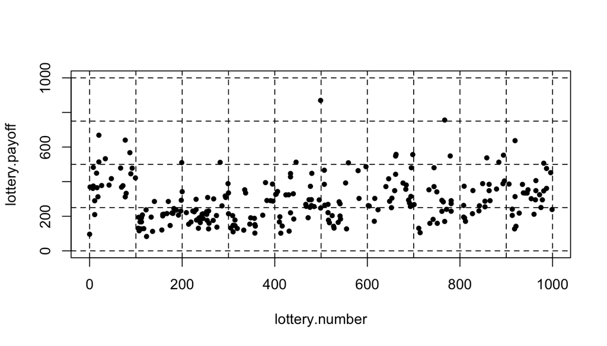

```r
plot(lottery.number, lottery.payoff,pch=20, ylim=c(0,1000))
abline(h=seq(0,1000,by=250),lty=2)
abline(v=seq(0,1000,by=100),lty=2)
```

- 흐름을 파악하기 위하여 local smoother, `lowess()` 를 활용.

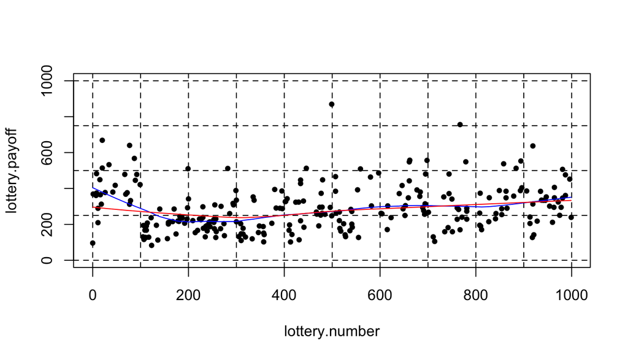

```r
plot(lottery.number, lottery.payoff,pch=20, ylim=c(0,1000))
abline(h=seq(0,1000,by=250),lty=2)
abline(v=seq(0,1000,by=100),lty=2)
lines(lowess(lottery.number,lottery.payoff, f=1/3),col="blue")
lines(lowess(lottery.number,lottery.payoff, f=2/3),col="red")
```

- 이제 당첨금액이 높은 당첨번호들은 숫자가 중복되는 경우가 많고, 당첨번호가 0에서 100 이하인 경우에 당첨금액이 높은지 생각해 보자. `detach(lottery)`를 하지 않고 `deatch()`만 해도 되는 이유는 뭘까? `save(file=filename, list=ls())` 와 같은 것이 `save.image(file=filename)` 임. 확인하기를

```r
detach()
par(opar)
save(file="./lottery.RData", list = ls())
```

```
savehistory("lottery.Rhistory")
```